# Report on Twitter

# Approach

In this report, I extracted data from https://twitter.com/Unilever via Twitter API to answer some of my questions on this communication channel of Unilever: - General performance - What kinds of posts appeal most to Internet users? - What are people talking about Unilever on the Internet? - Who are among the influencial users? - Sentiment analysis

# Improvement

- Although I got this twitter from the offical website of Unilever, twitter or facebook can only be a minor PR channel of the company. Therefore, the conclusion in this report might be incomprehensive, and we need more internal data to verify.
- There are many other factors that haven’t been counted in this report, such as marketing campaign. If I have more time working on this. I will cover competitors’ social data as well.

# Social Analysis

## General performance of Twitter

- In this section, I get data from Uniliever timeline since the beginning of 2017.

```r
# Get timeline tweets
# tweets <- userTimeline("Unilever", n = 3200)
# save(tweets, file="tweets.Rdata")
load("tweets.Rdata")
# tweets.df <- twListToDF(tweets)
# save(tweets.df, file="tweets.df.Rdata")
load("tweets.df.Rdata")
```

- Top tweets

```r
# List of top 10% tweet
top_tweet <- arrange(tweets.df, desc(favoriteCount)) %>%
  select(text, date_created, favoriteCount, retweetCount) %>%
  head(n=10) %>%
  datatable()
top_tweet
```

|  | text | date_created | favoriteCount | retweetCount |
| --- | --- | --- | --- | --- |
| 1 | We’ve achieved or are on track w/ 80% of our sustainability goals. Read how this is driving our growth… https://t.co/VFGUOSneJj | 2017-05-18 | 2048 | 576 |
| 2 | Today we announce our commitment to 100% recyclable #plastic packaging by 2025 #circulareconomy #SDG12… https://t.co/aKimetybPc | 2017-01-14 | 252 | 208 |
| 3 | Proud to announce the #UNSTEREOTYPE Alliance with @UN_Women to eradicate stereotypes in advertising #CannesLions… https://t.co/LrORhFtn5G | 2017-06-20 | 123 | 60 |
| 4 | Girls must get the education they deserve. Together we can fix this. @ONECampaign #PovertyIsSexist… https://t.co/zhRYjPU6SL | 2017-01-13 | 91 | 48 |
| 5 | "Gender equality is 170 years away. We cannot wait that long." Alan Jope our President of PC writes for @wef. #wef17 https://t.co/dlAVe2nA31 | 2017-01-19 | 90 | 89 |
| 6 | Read @PaulPolman in @thetimes on our commitment to make 100% of our plastic packaging recyclable by 2025 #wef17… https://t.co/ZHJ4qKEhQz | 2017-01-18 | 83 | 37 |
| 7 | Proud that Unilever’s @keithweed has been recognised as world's most influential CMO by @Forbes #CannesLions https://t.co/gZHPI8cEUg | 2017-06-22 | 80 | 32 |
| 8 | 62% of millennials want to work for a company that makes a positive impact. Join us. Value + Values #sustliving https://t.co/4B0BaTON53 | 2017-06-26 | 70 | 35 |
| 9 | We believe that advertising has the power to be a positive influence on culture https://t.co/lbdCfEEZ4R… https://t.co/D76K8PZJKO | 2017-06-19 | 70 | 46 |
| 10 | Today, just 14% of all plastic packaging globally is recycled. Solutions like CreaSolv aim to increase this.… https://t.co/S2umVUYBMG | 2017-05-11 | 66 | 48 |

- Time of the day with most tweets and most favorite

```r
top_time <- tweets.df %>%
  filter(favoriteCount<1000) %>%
  group_by(hour) %>%
  summarise(number_of_tweets=length(unique(id)),
            number_of_favorite=sum(favoriteCount),
            number_of_retweet=sum(retweetCount)) %>%
  mutate(avg_favorite=round(number_of_favorite/number_of_tweets, digit=0),
         avg_retweet=round(number_of_retweet/number_of_tweets, digit=0))

top_time <- filter(top_time, top_time$number_of_tweets > 1)

top_time <- datatable(top_time)
top_time
```

|  | hour | number_of_tweets | number_of_favorite | number_of_retweet | avg_favorite | avg_retweet |
| --- | --- | --- | --- | --- | --- | --- |
| 1 | 8 | 9 | 299 | 175 | 33 | 19 |
| 2 | 9 | 6 | 196 | 110 | 33 | 18 |
| 3 | 10 | 13 | 622 | 429 | 48 | 33 |
| 4 | 11 | 5 | 138 | 78 | 28 | 16 |
| 5 | 12 | 9 | 215 | 121 | 24 | 13 |
| 6 | 13 | 13 | 478 | 258 | 37 | 20 |
| 7 | 14 | 17 | 580 | 279 | 34 | 16 |
| 8 | 15 | 8 | 208 | 118 | 26 | 15 |
| 9 | 16 | 8 | 197 | 87 | 25 | 11 |
| 10 | 17 | 5 | 254 | 170 | 51 | 34 |

## What are people talking about Unilever

- In this section, I retrieve tweets that mention the word “Unilever”. Since the amount of data in this case is huge, I initially extracted data from July 18th until now.

```r
# Get tweets mentioning Unilever
# search_tweet <- searchTwitter("Unilever", n=20000)
# save(search_tweet, file="search_tweet.Rdata")
load("search_tweet.Rdata")
# search.tweet.df <- twListToDF(search_tweet)
# save(search.tweet.df, file="search.tweet.df.Rdata")
load("search.tweet.df.Rdata")
```

### Top people who tweet about Unilever

- I want to see who are the most influencial Twitter users whose tweets appeal alot of attention from other users. I use the average favorite per tweet in this case. Please note that I don’t take into account tweets from Paul Polman and Unilerver itself, obviously.

|  | screenName | number_of_tweets | number_of_favorite | number_of_retweet | avg_favorite | avg_retweet |
| --- | --- | --- | --- | --- | --- | --- |
| 1 | foe_us | 3 | 86 | 113 | 29 | 38 |
| 2 | Brexit | 2 | 42 | 61 | 21 | 30 |
| 3 | VegaSlager | 7 | 139 | 55 | 20 | 8 |
| 4 | Doener | 2 | 32 | 15 | 16 | 8 |
| 5 | business | 3 | 43 | 43 | 14 | 14 |
| 6 | SkyNews | 2 | 27 | 12 | 14 | 6 |
| 7 | 010byday | 2 | 22 | 6 | 11 | 3 |
| 8 | radiobakker | 2 | 22 | 22 | 11 | 11 |
| 9 | DrBirute | 2 | 18 | 5 | 9 | 2 |
| 10 | FT | 2 | 17 | 27 | 8 | 14 |

- On the other hand, I also see those users who tweet alot about Unilever. I remove the users that post a lot of stock updates, because they are out of this scope and also mislead the data. If I have more time, I will go mine more about this tweet data to see what are their concern.

|  | screenName | number_of_tweets | number_of_favorite | number_of_retweet | avg_favorite | avg_retweet |
| --- | --- | --- | --- | --- | --- | --- |
| 1 | _Economie | 61 | 0 | 2 | 0 | 0 |
| 2 | ACHelfensteijn | 26 | 0 | 0 | 0 | 0 |
| 3 | aex_top5 | 26 | 0 | 0 | 0 | 0 |
| 4 | mm_pak | 26 | 0 | 0 | 0 | 0 |
| 5 | Ratings_via_FL | 21 | 0 | 0 | 0 | 0 |
| 6 | equires | 20 | 0 | 0 | 0 | 0 |
| 7 | HandelNL | 17 | 0 | 0 | 0 | 0 |
| 8 | Kranten_en_RTV | 17 | 0 | 0 | 0 | 0 |
| 9 | AnimalRightsPh | 16 | 0 | 0 | 0 | 0 |
| 10 | AwesomeEK | 15 | 1 | 1 | 0 | 0 |

### Top words people use as they mention Unilever

- Most frenquently mentioned words apparently contain Pepsico and other brands such as Nestle, Procter&Gamble, as some of the biggest compititors in F&B industry.
- However, the most outstansing words in this case question us on environment issues related to Unilever. The presence of ‘Nestle’, ‘Pepsico’, ‘rainforest’, ‘destruction’, ‘elephants’ however, gives us a hint that people are having concern what these companies are doing with deforestation. I did some search and found some articles talking about Pepsico, Unilever and Nestlé being accused of complicity in illegal rainforest destruction, which leads to the “destruction of the last place on earth where Sumatran elephants, orangutans, rhinos and tigers”.

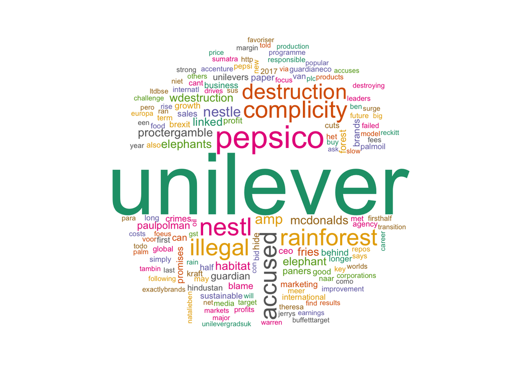

NULL

- More specifically, here is the frequency at which the words are mentioned around Unilever. This finding confirms the argument above as the words related to environment issues obviouly outnumber the others.

|  | term | freq |
| --- | --- | --- |
| 1 | unilever | 9817 |
| 2 | pepsico | 3144 |
| 3 | nestl | 2311 |
| 4 | accused | 2183 |
| 5 | complicity | 2175 |
| 6 | illegal | 2117 |
| 7 | rainforest | 2117 |
| 8 | destruction | 1886 |
| 9 | amp | 1010 |
| 10 | nestle | 984 |

[output cut: 10 more lines]

### Sentiment Analysis

- There are namely 3 ways in determining whether a word is negative or positive. (“nrc” - lexicon categorizes words of positive, negative, anger, anticipation, disgust, fear, joy, sadness, surprise, and trust. “bing”" lexicon categorizes words in a binary fashion into positive and negative categories. “AFINN” lexicon give a word a score from -5 to 5 (negative to positive). For this purpose I use “Bing”.
- This chart shows the different between the frequency of positive words and negative words. As it goes below 0, it shows more negative words are being used around “Unilever”.

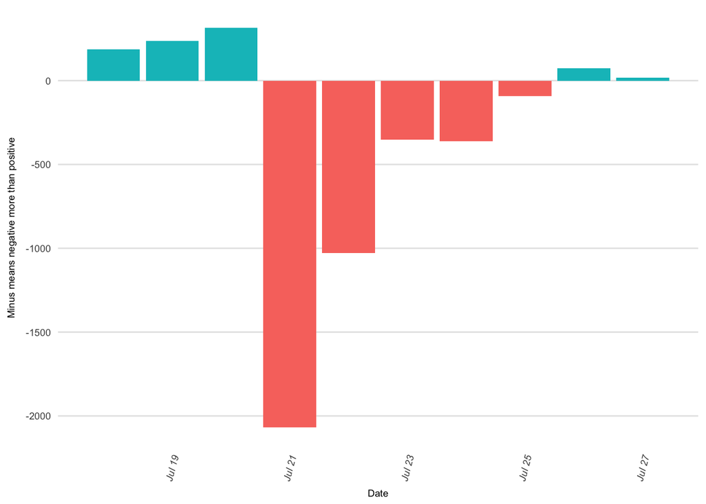

- Most common positive and negative words can be seen in this chart. It shows that people truly concern on enviromental practices that large FMCG corporates are implementing. People also talk about sustainability as a positive side.

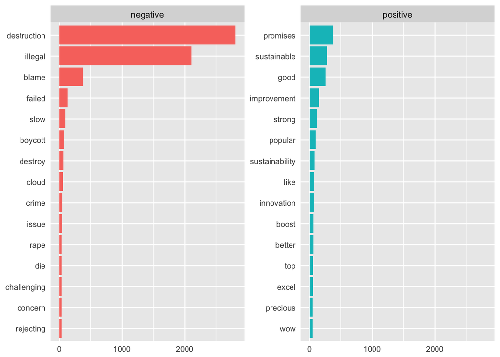

Source: local data frame [498 x 3] Groups: word [?]

```
      word sentiment     n
     <chr>     <chr> <int>
```

1 abuse negative 2 2 advanced positive 3 3 advantage positive 5 4 advocate positive 2 5 afford positive 1 6 agile positive 1 7 agility positive 1 8 allegations negative 3 9 allergy negative 1 10 amazing positive 7 # … with 488 more rows

- Data of the last 10 days show that people are talking about more negative things when it comes to Unilever, due to the rumor on illegal destruction. What needs to be done would be a stated commitment on environmental protection and sustainable manufacturing from Unilever and a join force from other companies in the industry. s